# OMDB API Movie Fetcher

Author

Jiahao Yuan, Yunfan Wu

Published

March 17, 2025

# OMDB API Movie Fetcher

This package allows you to interact with the OMDB API to fetch movie details based on some movie information. It provides functions to fetch accurate movie information using either a movie title or IMDB ID, or perform rough searches by partial title, and handle movie data in batches.

```r
library(OMDB.API)
```

## Functions

### `set.omdb.api.key()`

This function allows you to set your OMDB API key, which is required for making requests to the OMDB API. The API key will be stored in package environment.

#### Parameters:

- `api_key`: Your OMDB API key string (e.g., `"22bda3a2"`).

#### Example:

```r
set.omdb.api.key("22bda3a2")
```

### `unset.omdb.api.key()`

This function removes the OMDB API key from the environment, so that you can use set a new API key to the package environment.

#### Example:

```r
unset.omdb.api.key()
```

### `get.accurate.omdb.info()`

This function fetches detailed information for a movie, either by **IMDb ID** or **title**.

#### Parameters:

- `id`: The IMDb ID of the movie (e.g., `"tt1285016"`).
- `title`: The title of the movie (e.g., `"Avengers"`).
- `type`: The type of result, which can be `"movie"`, `"series"`, or `"episode"`.
- `year`: The release year of the movie.
- `plot`: The length of the plot to return (`"short"` or `"full"`).

#### Example:

```r
# Set your OMDB API key
set.omdb.api.key("22bda3a2")

# Fetch movie info by title
movie_info_1 <- get.accurate.omdb.info(title = "Avengers")
print(movie_info_1)
```

```
$Title
[1] "The Avengers"

$Year
[1] "2012"

$Rated
[1] "PG-13"

$Released
[1] "04 May 2012"

$Runtime
[1] "143 min"

$Genre
[1] "Action, Sci-Fi"

$Director
[1] "Joss Whedon"

$Writer
[1] "Joss Whedon, Zak Penn"

$Actors
[1] "Robert Downey Jr., Chris Evans, Scarlett Johansson"

$Plot
[1] "Earth's mightiest heroes must come together and learn to fight as a team if they are going to stop the mischievous Loki and his alien army from enslaving humanity."

$Language
[1] "English, Russian"

$Country
[1] "United States"

$Awards
[1] "Nominated for 1 Oscar. 39 wins & 81 nominations total"

$Poster
```

[output cut: 42 more lines]

```

$DVD
[1] "N/A"

$BoxOffice
[1] "$623,357,910"

$Production
[1] "N/A"

$Website
[1] "N/A"

$Response
[1] "True"
```

```r
# Fetch movie info by IMDb ID
movie_info_2 <- get.accurate.omdb.info(id = "tt1285016")
print(movie_info_2)
```

```
$Title
[1] "The Social Network"

$Year
[1] "2010"

$Rated
[1] "PG-13"

$Released
[1] "01 Oct 2010"

$Runtime
[1] "120 min"

$Genre
[1] "Biography, Drama"

$Director
[1] "David Fincher"

$Writer
[1] "Aaron Sorkin, Ben Mezrich"

$Actors
[1] "Jesse Eisenberg, Andrew Garfield, Justin Timberlake"

$Plot
[1] "As Harvard student Mark Zuckerberg creates the social networking site that would become known as Facebook, he is sued by the twins who claimed he stole their idea and by the co-founder who was later squeezed out of the business."

$Language
[1] "English, French"

$Country
[1] "United States"

$Awards
[1] "Won 3 Oscars. 174 wins & 188 nominations total"

$Poster
```

[output cut: 42 more lines]

```

$DVD
[1] "N/A"

$BoxOffice
[1] "$96,962,694"

$Production
[1] "N/A"

$Website
[1] "N/A"

$Response
[1] "True"
```

### `get.batch.accurate.omdb.info()`

This function allows you to fetch information for a **batch** of movies, given a list of IMDb IDs.

#### Parameters

- `ids`: A vector of IMDb IDs (e.g., `c("tt1285016", "tt1285017")`).

#### Example

```r
# Fetch information for multiple movies
movie_ids <- c("tt1285016", "tt1285017")
batch_info <- get.batch.accurate.omdb.info(ids = movie_ids)
print(batch_info)
```

```
[[1]]
[[1]]$Title
[1] "The Social Network"

[[1]]$Year
[1] "2010"

[[1]]$Rated
[1] "PG-13"

[[1]]$Released
[1] "01 Oct 2010"

[[1]]$Runtime
[1] "120 min"

[[1]]$Genre
[1] "Biography, Drama"

[[1]]$Director
[1] "David Fincher"

[[1]]$Writer
[1] "Aaron Sorkin, Ben Mezrich"

[[1]]$Actors
[1] "Jesse Eisenberg, Andrew Garfield, Justin Timberlake"

[[1]]$Plot
[1] "As Harvard student Mark Zuckerberg creates the social networking site that would become known as Facebook, he is sued by the twins who claimed he stole their idea and by the co-founder who was later squeezed out of the business."

[[1]]$Language
[1] "English, French"

[[1]]$Country
[1] "United States"

[[1]]$Awards
[1] "Won 3 Oscars. 174 wins & 188 nominations total"

```

[output cut: 127 more lines]

```

[[2]]$DVD
[1] "N/A"

[[2]]$BoxOffice
[1] "N/A"

[[2]]$Production
[1] "N/A"

[[2]]$Website
[1] "N/A"

[[2]]$Response
[1] "True"
```

### `get.rough.omdb.info()`

This function performs a rough search for movies based on a **partial title**, with optional filters like **minimum rating**, **genre**, and **sort order**.

#### Parameters

- `title`: The partial title of the movie (e.g., `"Avengers"`).
- `type`: The type of result, which can be `"movie"`, `"series"`, or `"episode"`.
- `year`: The release year of the movie to filter the results.
- `min_rating`: The minimum rating for the movie (e.g., 7).
- `genre`: The genre of the movie (e.g., `"Action"`).
- `sort_order`: The order in which the results are sorted (`"asc"`, `"desc"`, or `"none"`).

#### Example

```r
# Rough search for movies with title "Avengers" and minimum rating of 7
rough_results <- get.rough.omdb.info(title = "Avengers", min_rating = 7, genre = "Action")
print(rough_results)
```

```
                                    Title      Year   Type    imdbID
1                            The Avengers      2012  movie tt0848228
2                       Avengers: Endgame      2019  movie tt4154796
3                  Avengers: Infinity War      2018  movie tt4154756
4                 Avengers: Age of Ultron      2015  movie tt2395427
6  The Avengers: Earth's Mightiest Heroes 2010–2024 series tt1626038
8                            The Avengers 1961–1969 series tt0054518
10                      Avengers Assemble 2012–2019 series tt2455546
                                                                                                               Poster
1  https://m.media-amazon.com/images/M/MV5BNGE0YTVjNzUtNzJjOS00NGNlLTgxMzctZTY4YTE1Y2Y1ZTU4XkEyXkFqcGc@._V1_SX300.jpg
2                  https://m.media-amazon.com/images/M/MV5BMTc5MDE2ODcwNV5BMl5BanBnXkFtZTgwMzI2NzQ2NzM@._V1_SX300.jpg
3                  https://m.media-amazon.com/images/M/MV5BMjMxNjY2MDU1OV5BMl5BanBnXkFtZTgwNzY1MTUwNTM@._V1_SX300.jpg
4  https://m.media-amazon.com/images/M/MV5BODBhYTg1NGQtNGVmNS00ZTdiLThjYTYtZDFkNzRiNTZmNDZjXkEyXkFqcGc@._V1_SX300.jpg
6  https://m.media-amazon.com/images/M/MV5BY2NkYTNlMTQtZWVjNC00MTk4LTkzNGEtYjAyOTYxYWFjYTVkXkEyXkFqcGc@._V1_SX300.jpg
8  https://m.media-amazon.com/images/M/MV5BMDhhYWIxMzYtNTY2Zi00MTZiLWI2ZDUtYjNiNTY5YzA5MWNkXkEyXkFqcGc@._V1_SX300.jpg
10                 https://m.media-amazon.com/images/M/MV5BMTY0NTUyMDQwOV5BMl5BanBnXkFtZTgwNjAwMTA0MDE@._V1_SX300.jpg
                          Genre imdbRating
1                Action, Sci-Fi        8.0
2     Action, Adventure, Sci-Fi        8.4
3     Action, Adventure, Sci-Fi        8.4
4     Action, Adventure, Sci-Fi        7.3
6  Animation, Action, Adventure        8.3
8         Action, Comedy, Crime        8.3
10 Animation, Action, Adventure        7.0
```

```r
# Sort the results by IMDb rating in descending order
sorted_results <- get.rough.omdb.info(title = "Avengers", min_rating = 7, sort_order = "desc")
print(sorted_results)
```

```
                                    Title      Year   Type    imdbID
2                       Avengers: Endgame      2019  movie tt4154796
3                  Avengers: Infinity War      2018  movie tt4154756
6  The Avengers: Earth's Mightiest Heroes 2010–2024 series tt1626038
8                            The Avengers 1961–1969 series tt0054518
1                            The Avengers      2012  movie tt0848228
4                 Avengers: Age of Ultron      2015  movie tt2395427
10                      Avengers Assemble 2012–2019 series tt2455546
                                                                                                               Poster
2                  https://m.media-amazon.com/images/M/MV5BMTc5MDE2ODcwNV5BMl5BanBnXkFtZTgwMzI2NzQ2NzM@._V1_SX300.jpg
3                  https://m.media-amazon.com/images/M/MV5BMjMxNjY2MDU1OV5BMl5BanBnXkFtZTgwNzY1MTUwNTM@._V1_SX300.jpg
6  https://m.media-amazon.com/images/M/MV5BY2NkYTNlMTQtZWVjNC00MTk4LTkzNGEtYjAyOTYxYWFjYTVkXkEyXkFqcGc@._V1_SX300.jpg
8  https://m.media-amazon.com/images/M/MV5BMDhhYWIxMzYtNTY2Zi00MTZiLWI2ZDUtYjNiNTY5YzA5MWNkXkEyXkFqcGc@._V1_SX300.jpg
1  https://m.media-amazon.com/images/M/MV5BNGE0YTVjNzUtNzJjOS00NGNlLTgxMzctZTY4YTE1Y2Y1ZTU4XkEyXkFqcGc@._V1_SX300.jpg
4  https://m.media-amazon.com/images/M/MV5BODBhYTg1NGQtNGVmNS00ZTdiLThjYTYtZDFkNzRiNTZmNDZjXkEyXkFqcGc@._V1_SX300.jpg
10                 https://m.media-amazon.com/images/M/MV5BMTY0NTUyMDQwOV5BMl5BanBnXkFtZTgwNjAwMTA0MDE@._V1_SX300.jpg
                          Genre imdbRating
2     Action, Adventure, Sci-Fi        8.4
3     Action, Adventure, Sci-Fi        8.4
6  Animation, Action, Adventure        8.3
8         Action, Comedy, Crime        8.3
1                Action, Sci-Fi        8.0
4     Action, Adventure, Sci-Fi        7.3
10 Animation, Action, Adventure        7.0
```

## Usage Overview

To use the functions in this package, please follow these steps:

1. Set your OMDB API key using the `set.omdb.api.key()` function. After setting the OMDB API key, you can choose **Steps 2, 3, 4** freely to get your target movie information.
2. Use `get.accurate.omdb.info()` to fetch detailed movie information by IMDb ID or title.
3. Use `get.batch.accurate.omdb.info()` to fetch information for a batch of movies.
4. Use `get.rough.omdb.info()` for rough searches based on a partial title with additional filters (e.g., rating, genre).
5. After finishing, you can remove your API key using `unset.omdb.api.key()`.

## Data Visualization Examples

Let’s demonstrate how to create some visualizations using the movie data we fetch from OMDB API.

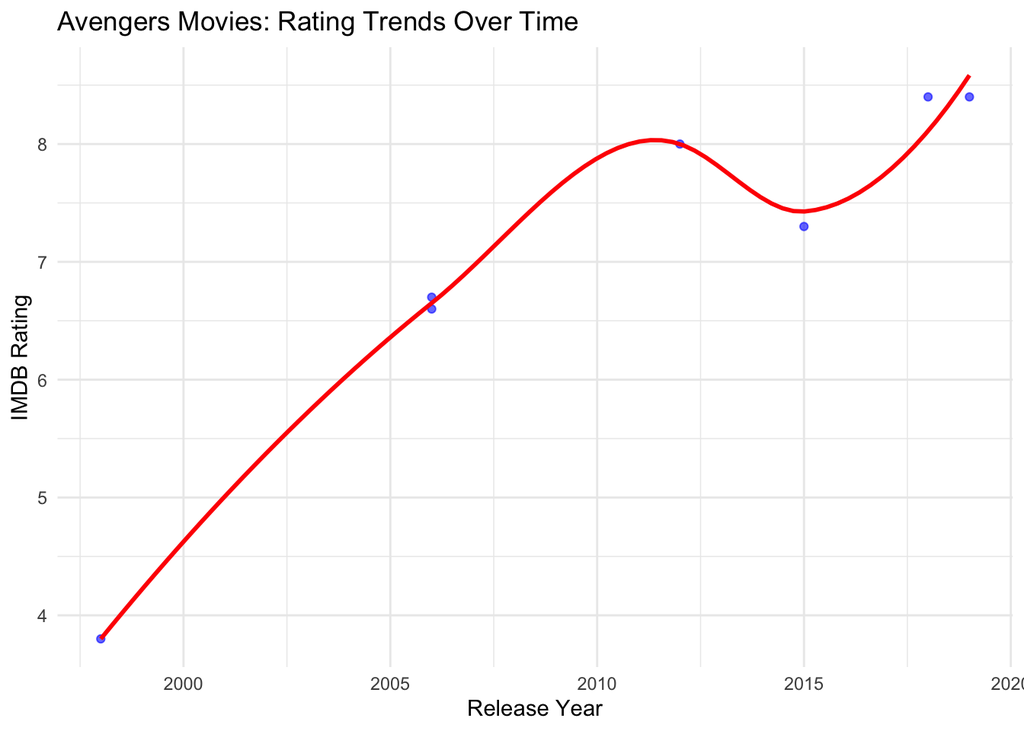

```r
library(ggplot2)
library(dplyr)
# Set API key for demonstration
set.omdb.api.key("22bda3a2")

# Get Avengers movies data
avengers_movies <- get.rough.omdb.info("Avengers", min_rating = 0)

# Basic data cleaning
avengers_movies$Year <- as.numeric(avengers_movies$Year)
avengers_movies$imdbRating <- as.numeric(avengers_movies$imdbRating)

# Create a simple scatter plot
ggplot(avengers_movies, aes(x = Year, y = imdbRating)) +
  geom_point(color = "blue", alpha = 0.6) +
  geom_smooth(method = "loess", se = FALSE, color = "red") +
  labs(title = "Avengers Movies: Rating Trends Over Time",
       x = "Release Year",
       y = "IMDB Rating") +
  theme_minimal()
```

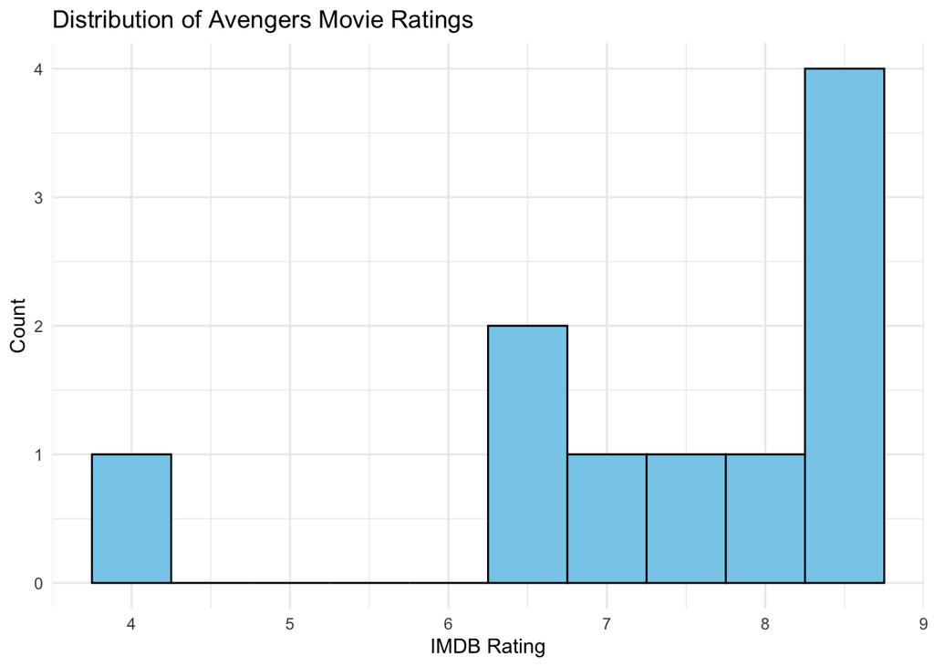

```r
# Create a simple histogram of ratings
ggplot(avengers_movies, aes(x = imdbRating)) +
  geom_histogram(binwidth = 0.5, fill = "skyblue", color = "black") +
  labs(title = "Distribution of Avengers Movie Ratings",
       x = "IMDB Rating",
       y = "Count") +
  theme_minimal()
```

These visualizations help us understand:

1. The first plot shows how Avengers movies’ ratings have changed over time, helping us identify any trends in movie quality over the years.
2. The second plot shows the distribution of ratings for Avengers-related movies, giving us an overview of how these movies typically perform.